# Machine Learning Workflow: XGBoost (MIMIC-IV Data)

Biostat 203B

Author

Li Zhang @ UCLA UID:206305918

Published

March 22, 2024

## 1 Setup

The goal is to predict whether a patient’s ICU stay will be longer than 2 days. You should use the `los_long` variable as the outcome.

## 2 MIMIC-IV Cohort

```r
library(GGally)
library(gtsummary)
library(tidyverse)
library(tidymodels)
library(dplyr)
library(rsample)

mimiciv_icu_cohort <- readRDS("../hw4/mimiciv_shiny/mimic_icu_cohort.rds")|>
  arrange(subject_id, hadm_id, stay_id)

# Numerical summaries stratified by the outcome `los_long`.
mimiciv_icu_cohort <- mimiciv_icu_cohort %>%
  select(
    -subject_id, -hadm_id, -stay_id, -los, -dod,
    -intime, -outtime, -admittime, -last_careunit,
    -dischtime, -deathtime, -admit_provider_id,
    -edregtime, -edouttime, -anchor_age,
    -anchor_year, -anchor_year_group,
    -discharge_location, -hospital_expire_flag
  ) %>%
mutate(los_long = as.factor(los_long))

tbl_summary(mimiciv_icu_cohort, by = los_long)
```

| **Characteristic** | **FALSE**, N = 38,050<sup>1</sup> | **TRUE**, N = 35,131<sup>1</sup> |
| --- | --- | --- |
| first_careunit |  |  |
| Cardiac Vascular Intensive Care Unit (CVICU) | 5,827 (15%) | 5,755 (16%) |
| Medical Intensive Care Unit (MICU) | 8,782 (23%) | 7,116 (20%) |
| Medical/Surgical Intensive Care Unit (MICU/SICU) | 7,147 (19%) | 5,586 (16%) |
| Surgical Intensive Care Unit (SICU) | 5,654 (15%) | 5,507 (16%) |
| Other | 10,640 (28%) | 11,167 (32%) |
| admission_type |  |  |
| EW EMER. | 20,735 (54%) | 17,937 (51%) |
| OBSERVATION ADMIT | 4,329 (11%) | 4,645 (13%) |
| SURGICAL SAME DAY ADMISSION | 4,340 (11%) | 3,033 (8.6%) |
| URGENT | 5,494 (14%) | 6,959 (20%) |
| Other | 3,152 (8.3%) | 2,557 (7.3%) |
| admission_location |  |  |
| EMERGENCY ROOM | 19,602 (52%) | 16,279 (46%) |
| PHYSICIAN REFERRAL | 8,986 (24%) | 7,412 (21%) |
| TRANSFER FROM HOSPITAL | 6,839 (18%) | 8,959 (26%) |
| WALK-IN/SELF REFERRAL | 876 (2.3%) | 791 (2.3%) |
| Other | 1,747 (4.6%) | 1,690 (4.8%) |
| insurance |  |  |
| Medicaid | 3,060 (8.0%) | 2,468 (7.0%) |
| Medicare | 16,489 (43%) | 16,602 (47%) |
| Other | 18,501 (49%) | 16,061 (46%) |
| language |  |  |
| ? | 3,692 (9.7%) | 3,751 (11%) |
| ENGLISH | 34,358 (90%) | 31,380 (89%) |
| marital_status |  |  |
| DIVORCED | 2,843 (8.0%) | 2,561 (7.9%) |
| MARRIED | 16,984 (48%) | 15,784 (49%) |
| SINGLE | 11,175 (31%) | 9,683 (30%) |
| WIDOWED | 4,699 (13%) | 4,339 (13%) |
| Unknown | 2,349 | 2,764 |
| race |  |  |
| Other | 5,160 (14%) | 5,596 (16%) |
| ASIAN | 1,148 (3.0%) | 1,007 (2.9%) |
| BLACK | 4,311 (11%) | 3,649 (10%) |
| HISPANIC | 1,492 (3.9%) | 1,249 (3.6%) |
| WHITE | 25,939 (68%) | 23,630 (67%) |
| gender |  |  |
| F | 17,014 (45%) | 15,349 (44%) |
| M | 21,036 (55%) | 19,782 (56%) |
| intimeage | 65 (53, 77) | 67 (56, 78) |
| Bicarbonate | 25.0 (22.0, 27.0) | 24.0 (21.0, 27.0) |
| Unknown | 4,270 | 4,780 |
| Glucose | 118 (98, 153) | 122 (100, 159) |
| Unknown | 4,282 | 4,817 |
| Sodium | 139.0 (136.0, 141.0) | 138.0 (135.0, 141.0) |
| Unknown | 4,174 | 4,698 |
| Chloride | 102 (98, 105) | 102 (98, 105) |
| Unknown | 4,175 | 4,708 |
| Hematocrit | 36 (30, 40) | 35 (29, 40) |
| Unknown | 2,236 | 2,781 |
| Potassium | 4.20 (3.80, 4.60) | 4.20 (3.80, 4.70) |
| Unknown | 4,189 | 4,712 |
| White Blood Cells | 9.0 (6.6, 12.6) | 9.7 (7.0, 13.8) |
| Unknown | 2,272 | 2,822 |
| Creatinine | 1.00 (0.80, 1.40) | 1.00 (0.80, 1.60) |
| Unknown | 2,599 | 3,171 |
| Respiratory Rate | 18.0 (15.0, 22.0) | 19.0 (15.0, 23.0) |
| Unknown | 85 | 10 |
| Non Invasive Blood Pressure diastolic | 68 (58, 80) | 66 (55, 79) |
| Unknown | 725 | 249 |
| Heart Rate | 85 (74, 99) | 88 (76, 103) |
| Unknown | 17 | 1 |
| Non Invasive Blood Pressure systolic | 122 (107, 139) | 120 (104, 138) |
| Unknown | 724 | 246 |
| Temperature Fahrenheit | 98.10 (97.60, 98.60) | 98.20 (97.60, 98.80) |
| Unknown | 1,180 | 173 |

<sup>1</sup> n (%); Median (IQR)

- We have following features available at an ICU stay’s `intime`:
  - Numerical features: `intimeage`, `Bicarbonate`, `Glucose`, `Sodium`, `Chloride`, `Hematocrit`, `Potassium`, `White Blood Cells`, `Creatinine`, `Respiratory Rate`, `Non Invasive Blood Pressure diastolic`, `Heart Rate`, `Non Invasive Blood Pressure systolic`, `Temperature Fahrenheit`.
  - Categorical features coded as string: `first_careunit`, `admission_type`, `admission_location`, `insurance`, `language`, `marital_status`, `race`, `gender`

## 3 Initial split into test and non-test sets

```r
set.seed(203)
data_split <- initial_split(
  mimiciv_icu_cohort,
  # stratify by los_long
  strata = "los_long",
  prop = 0.5
  )
data_split
```

```
<Training/Testing/Total>
<36590/36591/73181>
```

```r
mimic_other <- training(data_split)
dim(mimic_other)
```

```
[1] 36590    23
```

```r
mimic_test <- testing(data_split)
dim(mimic_test)
```

```
[1] 36591    23
```

## 4 Recipe

```r
gb_recipe <-
  recipe(
    los_long ~ .,
    data = mimic_other
  ) |>

  step_impute_mean(Bicarbonate) |>
  step_impute_mean(Glucose) |>
  step_impute_mean(Sodium) |>
  step_impute_mean(Chloride) |>
  step_impute_mean(Hematocrit) |>
  step_impute_mean(Potassium) |>
  step_impute_mean('White Blood Cells') |>
  step_impute_mean(Creatinine) |>
  step_impute_mean('Respiratory Rate') |>
  step_impute_mean('Non Invasive Blood Pressure diastolic') |>
  step_impute_mean('Heart Rate') |>
  step_impute_mean('Non Invasive Blood Pressure systolic') |>
  step_impute_mean('Temperature Fahrenheit') |>

  step_impute_mode(marital_status) |>

  # create traditional dummy variables
  step_dummy(all_nominal_predictors()) |>
  # zero-variance filter
  step_zv(all_numeric_predictors()) |>
  # center and scale numeric data
  step_normalize(all_numeric_predictors()) |>
  # estimate the means and standard deviations
  # prep(training = Heart_other, retain = TRUE) |>
  print()
```

[output not shown]

## 5 Model

```r
gb_mod <-
  boost_tree(
    mode = "classification",
    trees = 1000,
    tree_depth = tune(),
    learn_rate = tune()
  ) |>
  set_engine("xgboost")
gb_mod
```

```
Boosted Tree Model Specification (classification)

Main Arguments:
  trees = 1000
  tree_depth = tune()
  learn_rate = tune()

Computational engine: xgboost
```

## 6 Workflow

Here we bundle the recipe and model.

```r
gb_wf <- workflow() |>
  add_recipe(gb_recipe) |>
  add_model(gb_mod)
gb_wf
```

```
══ Workflow ════════════════════════════════════════════════════════════════════
Preprocessor: Recipe
Model: boost_tree()

── Preprocessor ────────────────────────────────────────────────────────────────
17 Recipe Steps

• step_impute_mean()
• step_impute_mean()
• step_impute_mean()
• step_impute_mean()
• step_impute_mean()
• step_impute_mean()
• step_impute_mean()
• step_impute_mean()
• step_impute_mean()
• step_impute_mean()
• ...
• and 7 more steps.

── Model ───────────────────────────────────────────────────────────────────────
Boosted Tree Model Specification (classification)

Main Arguments:
  trees = 1000
  tree_depth = tune()
  learn_rate = tune()

Computational engine: xgboost
```

## 7 Tuning grid

```r
param_grid <- grid_regular(
  tree_depth(range = c(1L, 3L)),
  learn_rate(range = c(-2, 4), trans = log10_trans()),
  levels = c(3, 10)
  )
param_grid
```

```
# A tibble: 30 × 2
   tree_depth learn_rate
        <int>      <dbl>
 1          1     0.01
 2          2     0.01
 3          3     0.01
 4          1     0.0464
 5          2     0.0464
 6          3     0.0464
 7          1     0.215
 8          2     0.215
 9          3     0.215
10          1     1
# ℹ 20 more rows
```

## 8 Cross-validation (CV)

Set cross-validation partitions.

```r
set.seed(203)

folds <- vfold_cv(mimic_other, v = 5)
folds
```

```
#  5-fold cross-validation
# A tibble: 5 × 2
  splits               id
  <list>               <chr>
1 <split [29272/7318]> Fold1
2 <split [29272/7318]> Fold2
3 <split [29272/7318]> Fold3
4 <split [29272/7318]> Fold4
5 <split [29272/7318]> Fold5
```

Fit cross-validation.

```r
gb_fit <- gb_wf |>
  tune_grid(
    resamples = folds,
    grid = param_grid,
    metrics = metric_set(roc_auc, accuracy),
    control=control_grid(verbose = TRUE)
    )
gb_fit
```

```
# Tuning results
# 5-fold cross-validation
# A tibble: 5 × 4
  splits               id    .metrics          .notes
  <list>               <chr> <list>            <list>
1 <split [29272/7318]> Fold1 <tibble [60 × 6]> <tibble [0 × 3]>
2 <split [29272/7318]> Fold2 <tibble [60 × 6]> <tibble [0 × 3]>
3 <split [29272/7318]> Fold3 <tibble [60 × 6]> <tibble [0 × 3]>
4 <split [29272/7318]> Fold4 <tibble [60 × 6]> <tibble [0 × 3]>
5 <split [29272/7318]> Fold5 <tibble [60 × 6]> <tibble [0 × 3]>
```

Visualize CV results:

```
# A tibble: 60 × 8
   tree_depth learn_rate .metric  .estimator  mean     n std_err
        <int>      <dbl> <chr>    <chr>      <dbl> <int>   <dbl>
 1          1     0.01   accuracy binary     0.584     5 0.00405
 2          1     0.01   roc_auc  binary     0.623     5 0.00343
 3          2     0.01   accuracy binary     0.596     5 0.00281
 4          2     0.01   roc_auc  binary     0.635     5 0.00343
 5          3     0.01   accuracy binary     0.604     5 0.00350
 6          3     0.01   roc_auc  binary     0.645     5 0.00353
 7          1     0.0464 accuracy binary     0.598     5 0.00324
 8          1     0.0464 roc_auc  binary     0.637     5 0.00298
 9          2     0.0464 accuracy binary     0.606     5 0.00224
10          2     0.0464 roc_auc  binary     0.649     5 0.00255
   .config
   <chr>
 1 Preprocessor1_Model01
 2 Preprocessor1_Model01
 3 Preprocessor1_Model02
 4 Preprocessor1_Model02
 5 Preprocessor1_Model03
 6 Preprocessor1_Model03
 7 Preprocessor1_Model04
 8 Preprocessor1_Model04
 9 Preprocessor1_Model05
10 Preprocessor1_Model05
# ℹ 50 more rows
```

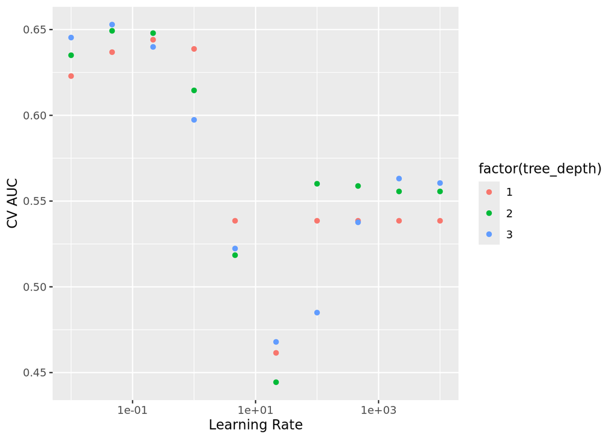

```r
gb_fit |>
  collect_metrics() |>
  print(width = Inf) |>
  filter(.metric == "roc_auc") |>
  ggplot(mapping = aes(x = learn_rate, y = mean, color = factor(tree_depth))) +
  geom_point() +
  labs(x = "Learning Rate", y = "CV AUC") +
  scale_x_log10()
```

Show the top 5 models.

```r
gb_fit |>
  show_best("roc_auc")
```

```
# A tibble: 5 × 8
  tree_depth learn_rate .metric .estimator  mean     n std_err .config
       <int>      <dbl> <chr>   <chr>      <dbl> <int>   <dbl> <chr>
1          3     0.0464 roc_auc binary     0.653     5 0.00286 Preprocessor1_Mo…
2          2     0.0464 roc_auc binary     0.649     5 0.00255 Preprocessor1_Mo…
3          2     0.215  roc_auc binary     0.648     5 0.00229 Preprocessor1_Mo…
4          3     0.01   roc_auc binary     0.645     5 0.00353 Preprocessor1_Mo…
5          1     0.215  roc_auc binary     0.644     5 0.00226 Preprocessor1_Mo…
```

Let’s select the best model.

```r
best_gb <- gb_fit |>
  select_best("roc_auc")
best_gb
```

```
# A tibble: 1 × 3
  tree_depth learn_rate .config
       <int>      <dbl> <chr>
1          3     0.0464 Preprocessor1_Model06
```

## 9 Finalize our model

Now we are done tuning. Finally, let’s fit this final model to the whole training data and use our test data to estimate the model performance we expect to see with new data.

```r
# Final workflow
final_wf <- gb_wf |>
  finalize_workflow(best_gb)
final_wf
```

```
══ Workflow ════════════════════════════════════════════════════════════════════
Preprocessor: Recipe
Model: boost_tree()

── Preprocessor ────────────────────────────────────────────────────────────────
17 Recipe Steps

• step_impute_mean()
• step_impute_mean()
• step_impute_mean()
• step_impute_mean()
• step_impute_mean()
• step_impute_mean()
• step_impute_mean()
• step_impute_mean()
• step_impute_mean()
• step_impute_mean()
• ...
• and 7 more steps.

── Model ───────────────────────────────────────────────────────────────────────
Boosted Tree Model Specification (classification)

Main Arguments:
  trees = 1000
  tree_depth = 3
  learn_rate = 0.0464158883361278

Computational engine: xgboost
```

```r
# Fit the whole training set, then predict the test cases
final_fit <-
  final_wf |>
  last_fit(data_split)
final_fit
```

```
# Resampling results
# Manual resampling
# A tibble: 1 × 6
  splits                id             .metrics .notes   .predictions .workflow
  <list>                <chr>          <list>   <list>   <list>       <list>
1 <split [36590/36591]> train/test sp… <tibble> <tibble> <tibble>     <workflow>
```

```r
# Test metrics
final_fit |>
  collect_metrics()
```

```
# A tibble: 2 × 4
  .metric  .estimator .estimate .config
  <chr>    <chr>          <dbl> <chr>
1 accuracy binary         0.609 Preprocessor1_Model1
2 roc_auc  binary         0.651 Preprocessor1_Model1
```

## 10 Visualize the final model

```r
library(rpart.plot)
final_tree <- extract_workflow(final_fit)
final_tree
```

```
══ Workflow [trained] ══════════════════════════════════════════════════════════
Preprocessor: Recipe
Model: boost_tree()

── Preprocessor ────────────────────────────────────────────────────────────────
17 Recipe Steps

• step_impute_mean()
• step_impute_mean()
• step_impute_mean()
• step_impute_mean()
• step_impute_mean()
• step_impute_mean()
• step_impute_mean()
• step_impute_mean()
• step_impute_mean()
• step_impute_mean()
• ...
• and 7 more steps.

── Model ───────────────────────────────────────────────────────────────────────
##### xgb.Booster
raw: 1.1 Mb
call:
  xgboost::xgb.train(params = list(eta = 0.0464158883361278, max_depth = 3L,
    gamma = 0, colsample_bytree = 1, colsample_bynode = 1, min_child_weight = 1,
    subsample = 1), data = x$data, nrounds = 1000, watchlist = x$watchlist,
    verbose = 0, nthread = 1, objective = "binary:logistic")
params (as set within xgb.train):
  eta = "0.0464158883361278", max_depth = "3", gamma = "0", colsample_bytree = "1", colsample_bynode = "1", min_child_weight = "1", subsample = "1", nthread = "1", objective = "binary:logistic", validate_parameters = "TRUE"
xgb.attributes:
  niter
callbacks:
  cb.evaluation.log()
# of features: 37
niter: 1000
nfeatures : 37
evaluation_log:
     iter training_logloss
    <num>            <num>
        1        0.6920529
        2        0.6910567
---
      999        0.6197721
     1000        0.6197304
```

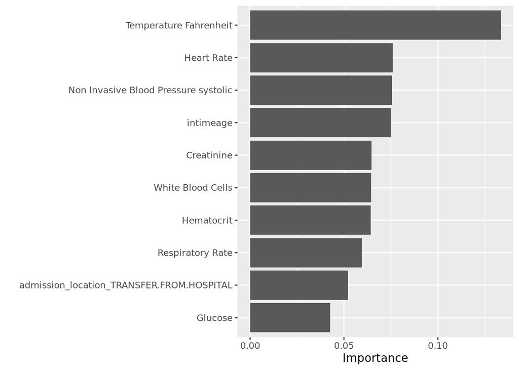

```r
library(vip)

final_tree %>%
  extract_fit_parsnip() %>%
  vip()
```